# Teoria Macroeconômica II - Artigo

Aishameriane Schmidt

5 de janeiro de 2018

# Dúvidas

1. **Tem como fazer alguma conversão dos valores pré-plano real para tributo do trabalho e capital para não perder as 30 primeiras observações?**

Aisha: *Não tem o que fazer.*

2. **Tem que fazer alguma coisa com a sazonalidade e tendência?**

Aisha: *É para usar o filtro automático mas explicar bem o que ele faz.*

3. **No artigo de bayesiana eu havia utilizado a SELIC overnight. Aí fui ver no site do Bacen e só tem a série `4390`- Taxa de juros (Selic acumulada no mês). Qual a diferença entre essas duas?**

Aisha: *Usar a SELIC do Bacen é melhor (depois tem que voltar aqui e escrever quais as diferenças entre essas séries e porque a do Bacen é melhor), porém tem que lembrar de passar para valores anuais (por enquanto estava mensal).* Update: *Fui procurar e entendi o que é a Selic Overnight (que tem no IPEA), mas ainda não entendi o que é a Selic acumulada no mês do Banco Central.* Update: *A Selic Acumulada no site do Bacen e a Selic Overnight do site do IPEA tem os mesmos valores. E a Selic Acumulada é feita usando a Selic diária (série `11`) com a fórmula de juros compostos.* **Agora resta saber por que a série `11` tem formato tão de escadinha.**

4. **Quais outras variáveis adicionar no modelo?**

Aisha: *Olhar o que o Muntaz usou no VAR dele. Basicamente procurar por produto, inflação, câmbio (talvez)…*

5. **Qual a temporalidade dos dados?**

Aisha: *De acordo com o Guilherme, se usar câmbio o melhor é fazer a partir do fim da âncora cambial*. Fui olhar e isso implica começar a série em Janeiro/99, quando foi adotado o regime de metas de inflação (http://www.rep.org.br/pdf/87-1.pdf). Por enquanto eu vou rodar desde 94 e depois eu adapto, se for o caso. Fui ver e a série do IBC-Br começa em 2003, daí fode tudo.

6. **O que é o equivalente tupiniquim de *three month treasury bill rate*?**

Aisha: Dá para usar isso? https://cran.r-project.org/web/packages/GetTDData/vignettes/gtdd-vignette_GetTDData.html . Update: O Portela disse o seguinte " *Oi Aisha, Você poderia usar a taxa do swap DI-Pré de 3 meses. Dá pra baixar do banco central ou então pelo BETS. Um abraço*“. No banco central, a série é `7818`- *Taxa referencial de swaps DI pré-fixada (BM&F) - Prazo de 90 dias (fim de período)*. **Mas eu não entendi que trem é esse… como que isso se relaciona com política monetária? E qual seria a justificativa para usar isso e não a taxa de juros da economia para colocar no VAR do Muntaz?**

7. **Log differences é a diferença dos logs ou o log da diferença?**

Aisha: Dar uma olhada no material de macro, uma delas era taxa de crescimento (diferença dos logs).

8. **Como calcular a taxa de crescimento da taxa de câmbio efetiva nominal?**

Aisha: Sei lá. O Muntaz usa *growth of the nominal effective exchange rate*, mas aí não sei se ele faz a diferença dos logs e por isso chama assim ou se ele calcula a taxa de crescimento e depois faz a diferença dos logs. **Eu posso dar uma olhada no código deles depois**.

# Baixando os dados

## Dependências dos pacotes

```r
list.of.packages <- c("ggplot2", "forecast", "BETS", "seasonal", "seasonalview", "bvarsv", "lubridate", "zoo", "stargazer", "gridExtra", "reshape2", "ggfortify", "RColorBrewer")
new.packages <- list.of.packages[!(list.of.packages %in% installed.packages()[,"Package"])]
if(length(new.packages)) install.packages(new.packages)

library(ggplot2, quietly = TRUE)
library(forecast, quietly = TRUE)
library(BETS, quietly = TRUE)
library(seasonal, quietly = TRUE)
library(seasonalview, quietly = TRUE)
library(bvarsv, quietly = TRUE)
library(lubridate, quietly = TRUE)
library(zoo, quietly = TRUE)
library(stargazer, quietly = TRUE)
library(gridExtra, quietly = TRUE)
library(reshape2, quietly = TRUE)
library(ggfortify, quietly = TRUE)
library(RColorBrewer, quietly = TRUE)
library(scales, quietly = TRUE)
```

Aisha: Caso o BETS não esteja instalado, retirar o `eval=FALSE` do chunk abaixo e rodar ele.

```r
library(devtools)
devtools::install_github("pedrocostaferreira/BETS", force= TRUE)
```

# Download dos dados

Os dados podem ser pegos de https://www3.bcb.gov.br/sgspub/localizarseries/localizarSeries.do?method=prepararTelaLocalizarSeries:

**Renda do trabalho**: Receitas tributárias - Regime de competência - Imposto de renda - Retido na fonte - Rendimento do trabalho (7620)

**Renda do capital**: Receitas tributárias - Regime de competência - Imposto de renda - Retido na fonte - Rendimento do capital (7621)

Ambas séries são mensais e começam em 31/01/1992. O último dado disponível em 05/01/2018 era de novembro de 2017, totalizando 311 meses. O pacote BETS consegue fazer download das séries apenas usando o código delas. Cortando em 1994 (por causa do plano real) ficam 281 observações (vou deixar para ver o trem da âncora cambial depois).

**Update:** Por enquanto estou incluindo IBC-Br o que me deixa com 177 observações apenas…

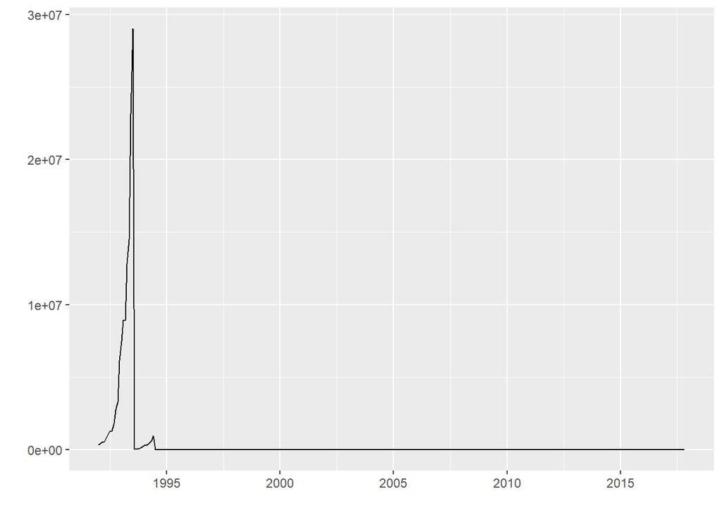

```r
trabalho <- BETS.get("7620")
capital <- BETS.get("7620")

autoplot(trabalho)
```

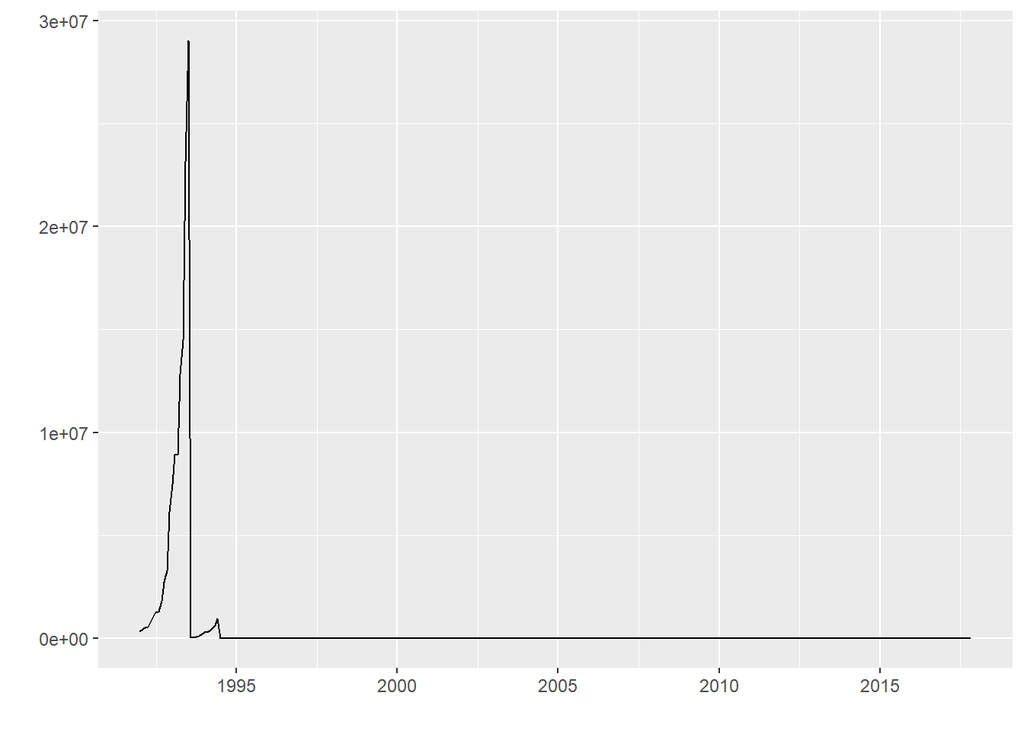

```r
autoplot(capital)
```

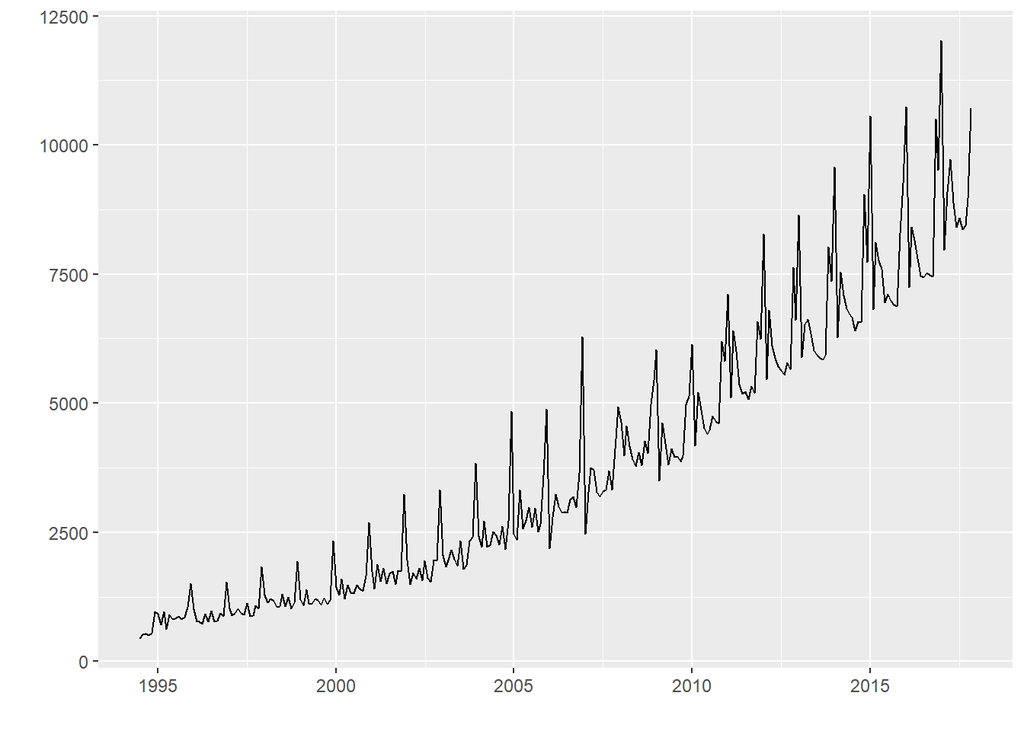

```r
trabalho <- BETS.get("7620", from = "1994-07-01", to = "2017-11-01")
autoplot(trabalho)
```

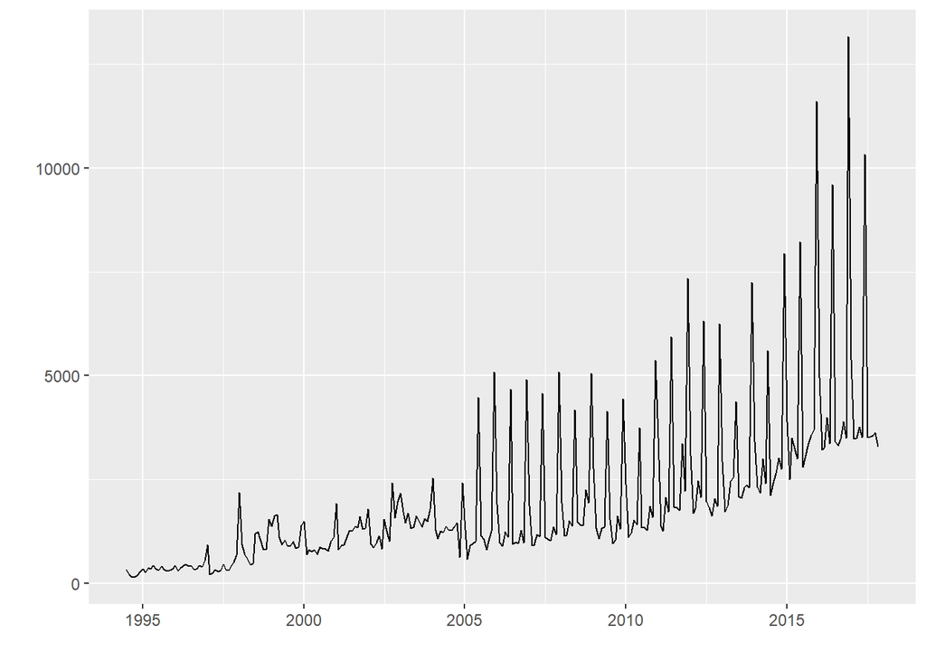

```r
capital <- BETS.get("7621", from = "1994-07-01", to = "2017-11-01")
autoplot(capital)
```

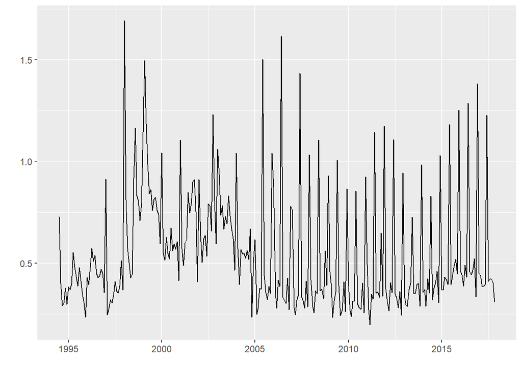

```r
capital_trabalho <- capital/trabalho
autoplot(capital/trabalho)
```

```r
length(capital_trabalho)
```

```
## [1] 281
```

Inicialmente eu fiz um primeiro VAR apenas com Selic e razão capital/trabalho. Havia a dúvida se era melhor usar a Selic do site do BACEN ou a Selic Overnight do site do IPEA. De acordo com o Guilherme, o melhor é o do Bacen pois é a efetiva (não entendi bem essa história…), mas lá em Bayesiana ele não me disse isso “*porque estava ocupado me ensinando o que era Selic*”.

## Uma digressão sobre as taxas de juros SELIC

Do site do Banco Central, tem essa definição: * “*Define-se Taxa Selic como a taxa média ajustada dos financiamentos diários apurados no Sistema Especial de Liquidação e de Custódia (Selic) para títulos federais. Para fins de cálculo da taxa, são considerados os financiamentos diários relativos às operações registradas e liquidadas no próprio Selic e em sistemas operados por câmaras ou prestadores de serviços de compensação e de liquidação*” ([Link](http://www.bcb.gov.br/htms/selic/conceito_taxaselic.asp?idpai=SELICTAXA)).

[Aqui tem uma explicação do que é a Selic Overnight](http://www.infomoney.com.br/noticias/noticia/2001536/entenda-relacao-entre-selic-fixada-pelo-copom-taxa-over-dos):

- “*(…) A Selic Over é obtida a partir do financiamento no mercado interbancário lastreado em títulos públicos, sendo calculada diariamente. (…) Essa taxa surge da necessidade de financiamento de quem está comprando títulos públicos.*” No site ainda tem um exemplo que ajuda a entender melhor.

Mas isso ainda não explica o que é a série `4390 - Taxa de juros - Selic acumulada no mês` que tem no sistema do Banco Central. Olhando na caixinha de explicações metodológicas, diz que ela é derivada da série `11 - Taxa de Juros - Selic`. Essa taxa `11` está em `%a.d.`. Então vou pegar uns valores para ver o que acontece:

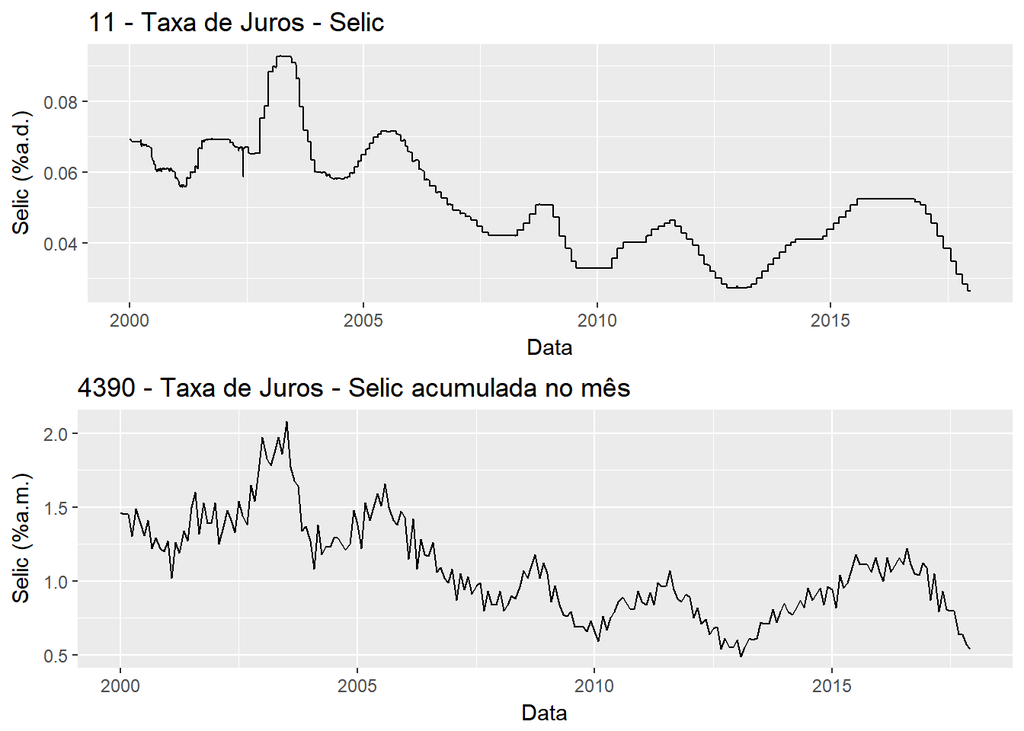

```r
selic_11   <- BETS.get("11",   from = "2000-01-01", to = "2017-12-31")
#head(selic_11)
selic_4390 <- BETS.get("4390", from = "2000-01-01", to = "2017-12-31")
#head(selic_4390)

df1 <- as.data.frame(selic_11)
#head(df1)

p1 <- ggplot(df1, aes(date, value)) +
        geom_line() +
        scale_x_date() +
        xlab("Data") +
        ylab("Selic (%a.d.)") +
        ggtitle("11 - Taxa de Juros - Selic")


df2 <- data.frame(time(selic_4390), as.numeric(selic_4390))
#head(df2)
names(df2) <- c("date", "value")

p2 <- ggplot(df2, aes(date, value)) +
        geom_line() +
        xlab("Data") +
        ylab("Selic (%a.m.)") +
        ggtitle("4390 - Taxa de Juros - Selic acumulada no mês")

grid.arrange(p1, p2, ncol=1, nrow = 2)
```

Depois disso, eu peguei ambas séries de janeiro de 2017 a dezembro de 2017 e na série diária eu somei os valores de cada mês, para obter 12 valores e comparei com os 12 valores da série `4390`. Os valores são bem similares. Depois eu tentei fazer um puxadinho do que é a fórmula nos dados básicos da série `4390`, onde diz `CONVPER((ACMVALORES(((SERIE(11)/100)+1),"mensal","multiplicacao")-1)*100,"mensal","ultimovalor")`. O que eu fiz no Excel foi pegar cada valor, dividir por $100$ e somar $1$. Depois disso, multipliquei os valores dentro de um mesmo mês, subtraí $1$ e multipliquei por $100$.

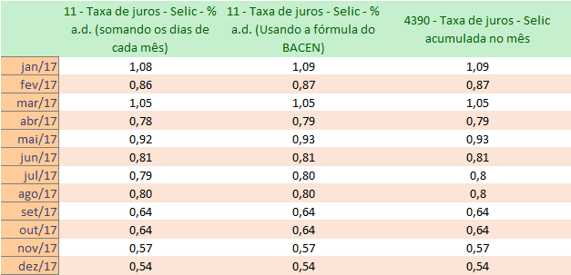

Comparação da série 11 com a série 4390

Resumindo, o que tem na série `4390` parece ser a fórmula de juros compostos usando os valores da série `11`, que por sua vez tem valores do tipo “escadinha”.

Agora, vou olhar para a Selic Overnight, do site do IPEA.

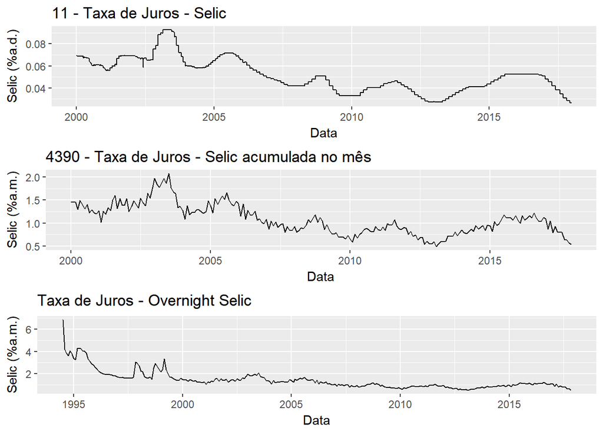

```r
selic_overnight <- read.csv2("C:\\Users\\Aishameriane\\OneDrive\\Documentos\\Mestrado Economia\\Teoria Macroeconômica II - 2017-2\\Artigo\\Aplicação\\selic_overnight.csv", sep = ";", dec = ",", header = TRUE)
selic_overnight <- selic_overnight[,-3]
colnames(selic_overnight) <- c("Data", "Selic")

# Arrumando as datas
selic_overnight[,1]<-paste(selic_overnight[,1], ".01", sep="")
selic_overnight[,1]<-ymd(selic_overnight[,1])

inicio <- which(selic_overnight[,1] == "1994-07-01")
fim <- which(selic_overnight[,1] == "2017-11-01")
selic_overnight<-selic_overnight[inicio:fim,]

p3 <- ggplot(selic_overnight, aes(Data, Selic)) +
        geom_line() +
        xlab("Data") +
        ylab("Selic (%a.m.)") +
        ggtitle("Taxa de Juros - Overnight Selic")

grid.arrange(p1, p2, p3, ncol=1, nrow = 3)
```

Eu estou desconfiada que a Overnight e a série `4390` são a mesma coisa, então vou dropar uns valores da overnight e ver o que acontece.

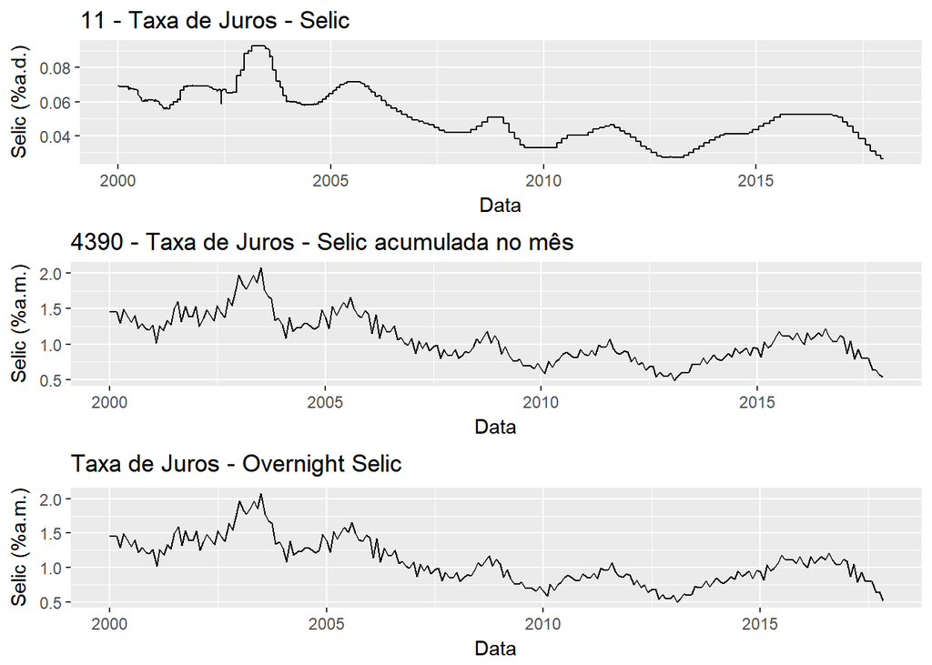

```r
inicio <- which(selic_overnight[,1] == "2000-01-01")
fim <- which(selic_overnight[,1] == "2017-11-01")
selic_overnight_menor<-selic_overnight[inicio:fim,]

p4 <- ggplot(selic_overnight_menor, aes(Data, Selic)) +
        geom_line() +
        xlab("Data") +
        ylab("Selic (%a.m.)") +
        ggtitle("Taxa de Juros - Overnight Selic")

grid.arrange(p1, p2, p4, ncol=1, nrow = 3)
```

Os gráficos são bem similares… Mas e os valores? (obs: eu olhei para os valores da cauda também e usei janelas maiores de dados… só os dois últimos não são iguais na segunda casa decimal.)

```r
cbind(head(round(selic_overnight_menor[,2],2), 10), head(selic_4390[1:(length(selic_4390)-1)], 10))
```

```
##       [,1] [,2]
##  [1,] 1.46 1.46
##  [2,] 1.45 1.45
##  [3,] 1.45 1.45
##  [4,] 1.30 1.30
##  [5,] 1.49 1.49
##  [6,] 1.39 1.39
##  [7,] 1.31 1.31
##  [8,] 1.41 1.41
##  [9,] 1.22 1.22
## [10,] 1.29 1.29
```

E acho que isso resolve uma parte do mistério. A série `4390` e a série `Selic Overnight` do site do IPEA de fato parecem ser a mesma série. E elas são o resultado da fórmula de juros compostos na série `11`. Aisha: **Agora resta saber por que a série `11` tem formato tão de escadinha.**

Como é mais fácil de pegar os dados usando o pacote BETS, eu vou usar a série `selic_4390` como a série “oficial”. Agora resta baixar os dados da série inteira (jul-94 até dez-17) e anualizar.

```r
selic_4390 <- BETS.get("4390", from = "1994-07-01", to = "2017-12-31")

## Transformando em série anual
selic <- ((1+selic_4390/100)^(12)-1)*100
head(selic)
```

```
##            Jul       Aug       Sep       Oct       Nov       Dec
## 1994 121.95744  63.27210  56.99082  53.22268  61.40116  56.44736
```

```r
tail(selic)
```

```
##            Jul       Aug       Sep       Oct       Nov       Dec
## 2017 10.033869 10.033869  7.956187  7.956187  7.058561  6.675963
```

```r
length(selic)
```

```
## [1] 282
```

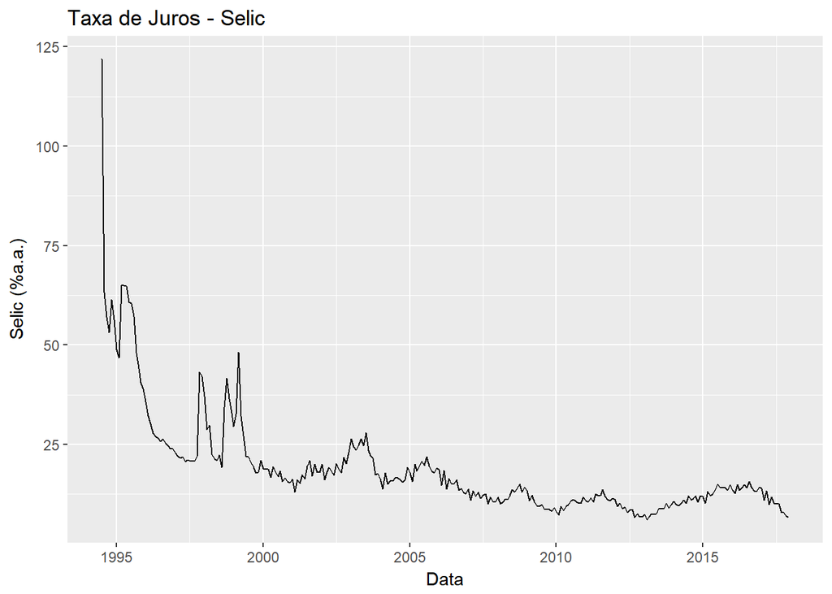

```r
df2 <- data.frame(time(selic), as.numeric(selic))
names(df2) <- c("Data", "Selic")

p5 <- ggplot(df2, aes(Data, Selic)) +
        geom_line() +
        xlab("Data") +
        ylab("Selic (%a.a.)") +
        ggtitle("Taxa de Juros - Selic")

p5
```

Os valores do início da série estão meio ruins, mas depois eu me preocupo com isso se for o caso. Tem outra coisa me incomodando que os valores estão meio diferentes do que tem no site do Bacen: https://www.bcb.gov.br/Pec/Copom/Port/taxaSelic.asp. Aí não sei se eu não fiz merda na hora de converter a taxa.

**Fim da digressão sobre a SELIC**

## Pegando os outros dados

As variáveis do modelo do Muntaz são:

- PIB per capita (*real GDP per capita*) - peguei IBC-Br `24364` que já tem ajuste sazonal (problema é que a série começa em janeiro de 2003 e acaba em outubro de 2017);
- Inflação (*CPI inflation*) - peguei IPCA `433` que já está em variação percentual mensal;
- *Three month treasury bill rate* - falei com o Portela e ele sugeriu usar a série `7818` *Taxa referencial de swaps DI pré-fixada (BM&F) - Prazo de 90 dias (fim de período)* (ela tem valores de 30/09/1999 a desembro de 2017);
- Taxa de crescimento da taxa de câmbio efetiva nominal (*growth of the nominal effective exchange rate*) - mínima ideia de como calcular isso também. Peguei a série que o Portela usava em séries temporais: `3696` - taxa de câmbio livre - dólar americano (venda) fim de período mensal.

Todas as variáveis exceto as de desigualdade e a taxa de juros estão em *log differences* (aqui não sei se é o log da diferença ou a diferença dos logs - **tenho que pensar**).

### PIB Per capita

Bom, não tem PIB per capita, então tem que ser IBC-Br.

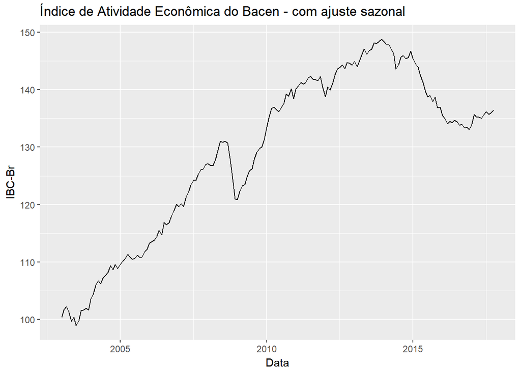

```r
ibcbr <- BETS.get("24364", from = "1994-07-01", to = "2017-12-31")

df3 <- data.frame(time(ibcbr), as.numeric(ibcbr))
names(df3) <- c("Data", "IBCBr")

p6 <- ggplot(df3, aes(Data, IBCBr)) +
        geom_line() +
        xlab("Data") +
        ylab("IBC-Br") +
        ggtitle("Índice de Atividade Econômica do Bacen - com ajuste sazonal")

p6
```

LEMBRETE: Esse trem tem uma tendência monstra, depois tem que ver isso. Tirei a diferença da série em log.

LEMBRETE: **A série começa em janeiro de 2003… Daí fica com 178 dados… tem que ver com o Guilherme depois.**

### Inflação

Para inflação usei a série `433`, do IPCA. Tem duas coisas que podem ser feitas, uma é calcular o índice acumulado no ano (o que não parece interessante porque implica que todo início de ano teria uma queda) e a segunda é calcular o índice acumulado nos últimos 12 meses. Para fazer a segunda, tem que primeiro pegar todos os valores da série e dividir por 100 e depois acrescentar 1. Dessa nova série, são multiplicados os 12 valores anteriores (incluindo o atual), desconta um e multiplica por 100.

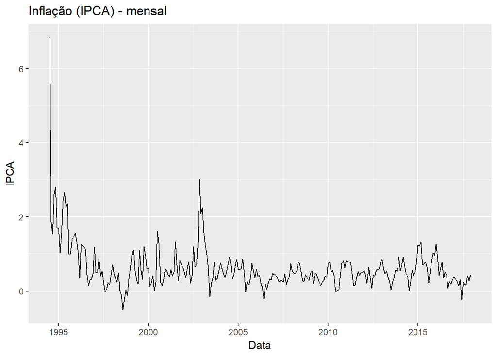

```r
# Primeiro um gráfico simples
ipca <- BETS.get("433", from = "1994-07-01", to = "2017-12-31")

df4 <- data.frame(time(ipca), as.numeric(ipca))
names(df4) <- c("Data", "IPCA")

p7 <- ggplot(df4, aes(Data, IPCA)) +
        geom_line() +
        xlab("Data") +
        ylab("IPCA") +
        ggtitle("Inflação (IPCA) - mensal")

p7
```

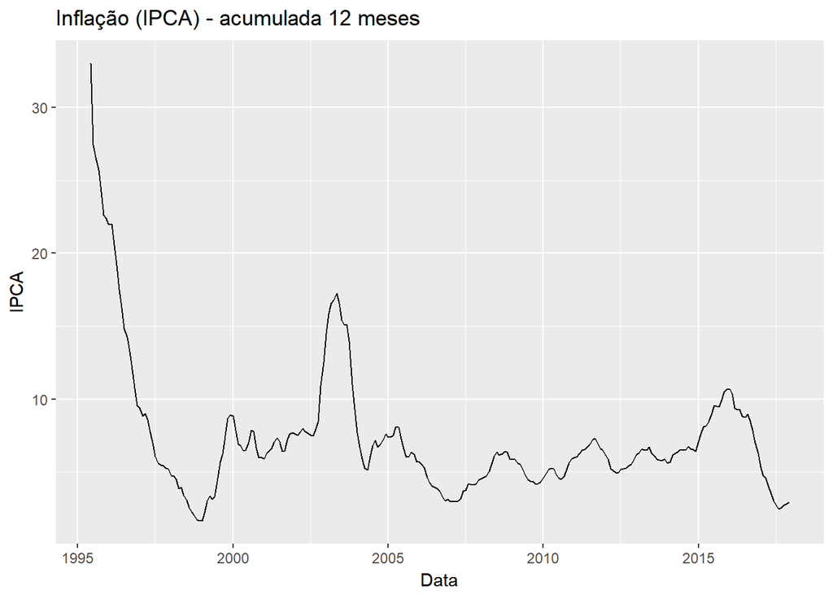

```r
# Agora a inflação acumulada em 12 meses
ipca_acum <- ipca/100 + 1
ipca_acum2 <- vector()

for (i in 12:282){
  ipca_acum2[(i-11)] <- (prod(ipca_acum[(i-11):i])-1)*100
}
ipca_acum2 <- ts(ipca_acum2,  start = c(1995, 6, 1), frequency = 12)

df4 <- data.frame(time(ipca_acum2), as.numeric(ipca_acum2))
names(df4) <- c("Data", "IPCA")

p8 <- ggplot(df4, aes(Data, IPCA)) +
        geom_line() +
        xlab("Data") +
        ylab("IPCA") +
        ggtitle("Inflação (IPCA) - acumulada 12 meses")

p8
```

Eu conferi os valores com [isso aqui](http://www.valor.com.br/brasil/5110008/ipca-desacelera-em-agosto-e-completa-12-meses-consecutivos-de-queda) e bateu. *Já posso pedir a carteirinha de economista, yay!*

Aisha: **De novo tem aquelas valores ruins no início da série, acho que vou ter mesmo que eliminar uns valores.**

### Three month treasury bill rate

Depois de falar com o Portela, cheguei nessa série aqui: `7818` *Taxa referencial de swaps DI pré-fixada (BM&F) - Prazo de 90 dias (fim de período)* . Eu ainda não sei como que isso se relaciona a uma taxa de juros (no sentido de instrumento de política monetária), mas vou deixar os dados aqui guardados por enquanto.

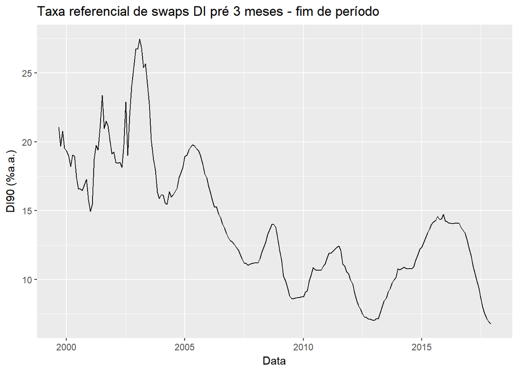

```r
swap90 <- BETS.get("7818", from = "1999-09-01", to = "2017-12-31")

df7 <- data.frame(time(swap90), as.numeric(swap90))
names(df7) <- c("Data", "DI90")

p10 <- ggplot(df7, aes(Data, DI90)) +
        geom_line() +
        xlab("Data") +
        ylab("DI90 (%a.a.)") +
        ggtitle("Taxa referencial de swaps DI pré 3 meses - fim de período")

p10
```

Vou tentar comparar com a SELIC. **Será que essas duas taxas são comparáveis?** *Acho que sim porque eu passei SELIC para %a.a. também…*.

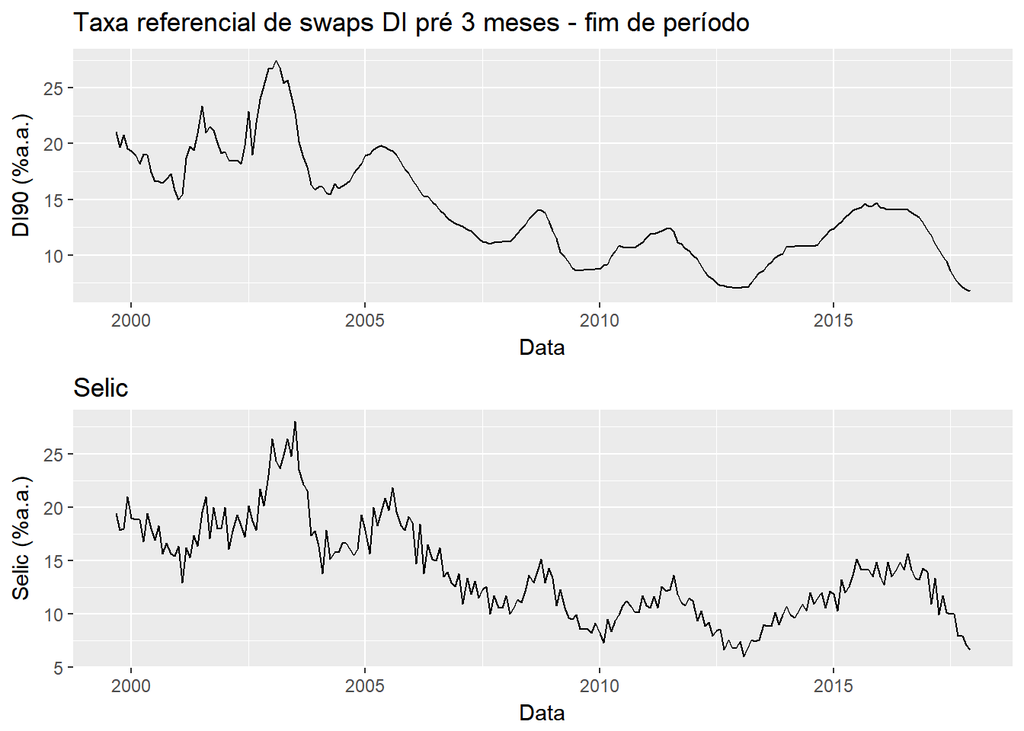

```r
selic_4390 <- BETS.get("4390", from = "1999-09-01", to = "2017-12-31")

## Transformando em série anual
selic <- ((1+selic_4390/100)^(12)-1)*100
df10 <- data.frame(time(selic), as.numeric(selic))
names(df10) <- c("Data","Selic")
p11 <- ggplot(df10, aes(Data, Selic)) +
        geom_line() +
        xlab("Data") +
        ylab("Selic (%a.a.)") +
        ggtitle("Selic")

grid.arrange(p10, p11, ncol=1, nrow = 2)
```

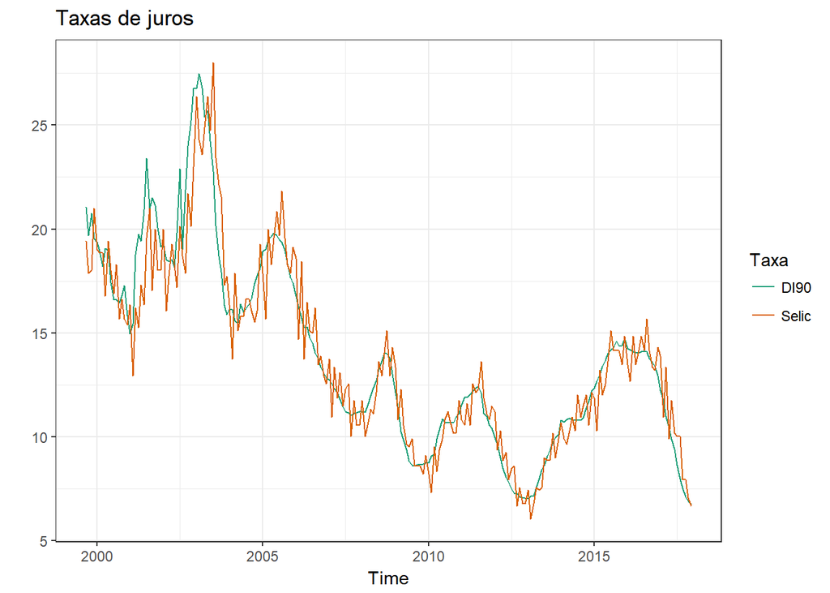

```r
df8 <- data.frame(df7, selic)
names(df8) <- c("Data", "DI90", "Selic")

df9 <- melt(data = df8, id.vars = "Data")

ggplot(df9, aes(Data, value, colour = variable)) +
  geom_line(alpha = 1)+
  labs(title="Taxas de juros", y = "", x= "Time", color = "Taxa") +
  scale_colour_brewer(palette = "Dark2") +
  theme_bw()
```

Elas são praticamente iguais, então vou ficar com a Selic.

### Câmbio

Do câmbio, tem essas séries no Bacen:

- **Taxa de câmbio - Livre - Dólar americano (compra) - Média de período - mensal**: número da série 3697, peridiocidade mensal, unidade u.m.c./US$.
- **Taxa de câmbio - Livre - Dólar americano (venda) - Fim de período - mensal**: número da série 3696, peridiocidade mensal, unidade u.m.c./US$.

Como o Portela usa a segunda, vou usar a segunda (argumento de autoridade).

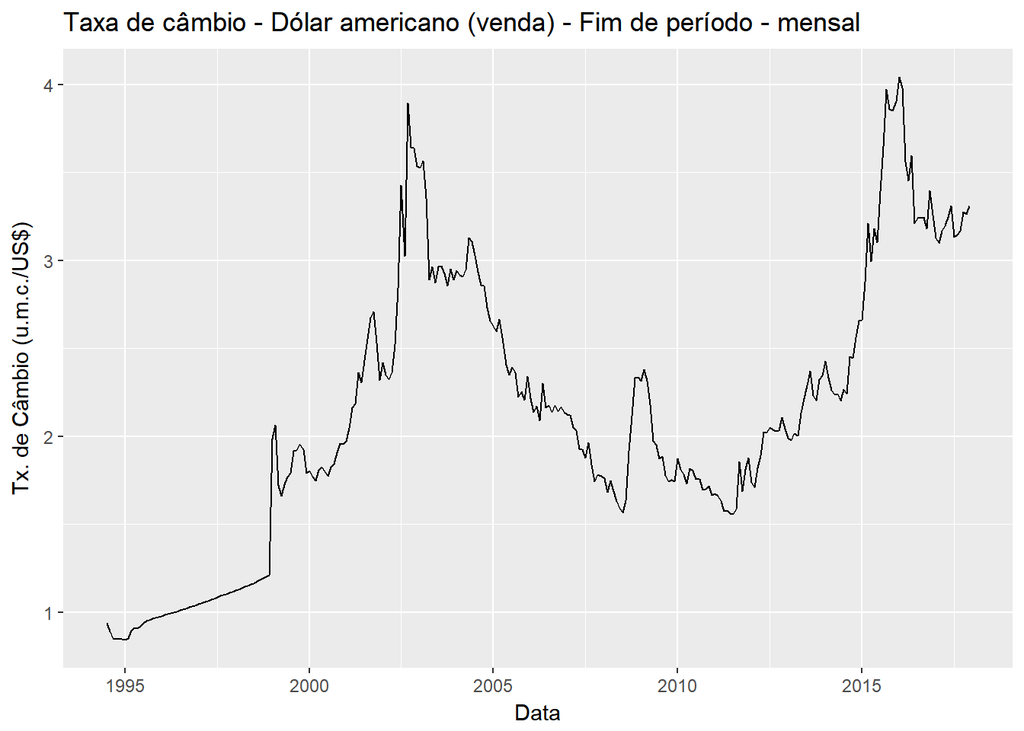

```r
cambio <- BETS.get("3696", from = "1994-07-01", to = "2017-12-31")

df5 <- data.frame(time(cambio), as.numeric(cambio))
names(df5) <- c("Data", "Cambio")

p8 <- ggplot(df5, aes(Data, Cambio)) +
        geom_line() +
        xlab("Data") +
        ylab("Tx. de Câmbio (u.m.c./US$)") +
        ggtitle("Taxa de câmbio - Dólar americano (venda) - Fim de período - mensal")

p8
```

Realmente a partir de 99 que as coisas começaram a ficar diferentes.

Vou tentar calcular a taxa de crescimento usando a diferença dos logaritmos.

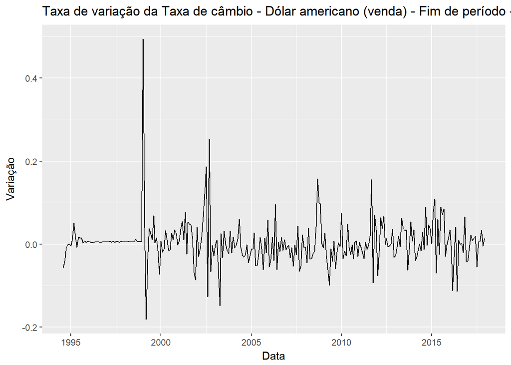

```r
cambio_cres <- diff(log(cambio), 1)

df6 <- data.frame(time(cambio_cres), as.numeric(cambio_cres))
names(df6) <- c("Data", "Cambio")

p9 <- ggplot(df6, aes(Data, Cambio)) +
        geom_line() +
        xlab("Data") +
        ylab("Variação") +
        ggtitle("Taxa de variação da Taxa de câmbio - Dólar americano (venda) - Fim de período - mensal")

p9
```

De fato vai ter que tirar fora a parte antes de 1999.

## Todos os dados juntos

A lista de dados que tenho até agora é:

1. Razão capital-trabalho (para desigualdade), calculada a partir das seguintes séries:
   - **Renda do trabalho**: `Receitas tributárias - Regime de competência - Imposto de renda - Retido na fonte - Rendimento do trabalho (7620)`
   - **Renda do capital**: `Receitas tributárias - Regime de competência - Imposto de renda - Retido na fonte - Rendimento do capital (7621)` Não foi feita nenhuma transformação nos dados.
2. Taxa Selic (em substituição à *three month treasury bill rate*) calculada a partir da série:
   - `Taxa de juros - Selic acumulada no mês (4390)` Eu comparei com a taxa referencial de swaps DI pré-fixada e ambas são praticamente a mesma coisa, então fiquei com a Selic mesmo. A única transformação feita (até agora) foi passar de taxa mensal para anual usando a fórmula: $\left((1+tx/100)^12 -1\right)*100$.
3. IPCA (para inflação), utilizando a seguinte série:
   - `Índice nacional de preços ao consumidor-amplo (IPCA) (433)` Como ele está em variação percentual mensal, foi necessário transformar para acumulado dos últimos 12 meses utilizando a fórmula:
     $$IPCA_i = \left[\left(\prod\limits_{j=i-11}^i \left(\frac{IPCA_j}{100}+1\right) \right) -1\right]*100$$
4. IBC-Br (para o PIB per capita), utilizando a seguinte série:
   - `Índice de Atividade Econômica do Banco Central (IBC-Br) - com ajuste sazonal (24364)` Não fiz nenhuma transformação por enquanto, mas o bicho tem uma baita tendência. Fiz a diferença da série em log, igual o câmbio.
5. Crescimento da taxa de câmbio (para *growth of the nominal effective exchange rate*). Usei a série:
   - `Taxa de câmbio - Livre - Dólar americano (venda) - Fim de período - mensal (3696)` Como o Muntaz disse que usou log diferença, eu calculei o log e tirei primeira diferença nessa série. As outras eu ainda não fiz, porque o IBC-Br é índice e a inflação também…

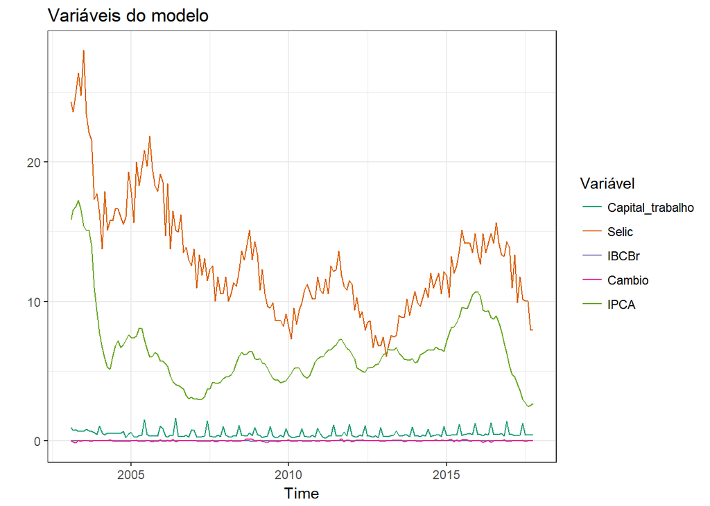

```r
rm(list = ls())

# Auxiliary variables, so I don't need to bother when something changes
inicio <- "2003-02-01"
fim    <- "2017-10-31"

# Don't mess with this code
inicio_cambio <- paste(seq(as.Date(inicio), length = 2, by = "-1 month")[2]) # 1 mês antes do início das outras séries
inicio_ipca   <- paste(seq(as.Date(inicio), length = 12, by = "-1 month")[12]) # 12 meses antes do início das outras séries

trabalho <- BETS.get("7620", from = inicio, to = fim)
capital  <- BETS.get("7621", from = inicio, to = fim)
capital_trabalho <- capital/trabalho

# Usando ndiffs(ibcbr,test="adf",alpha = 0.1) se encontra que o ibcbr é não estacionário.
# Como todas as outras séries são estacionárias, eu vou fazer também a diferença do log, igual no câmbio
ibcbr_raw    <- BETS.get("24364", from = inicio_cambio, to = fim)
ibcbr        <- diff(log(ibcbr_raw), 1)

cambio_raw <- BETS.get("3696", from = inicio_cambio, to = fim)
cambio     <- diff(log(cambio_raw), 1)

selic_4390 <- BETS.get("4390", from = inicio, to = fim)
selic <- ((1+selic_4390/100)^(12)-1)*100

ipca_raw <- BETS.get("433", from = inicio_ipca, to = fim)
ipca_acum <- ipca_raw/100 + 1
ipca <- vector()

final <- length(ipca_acum)
for (i in 12:final){
  ipca[(i-11)] <- (prod(ipca_acum[(i-11):i])-1)*100
}

ano <- as.numeric(substr(inicio, start = 1, stop = 4))
mes <- as.numeric(substr(inicio, start = 6, stop = 7))
dia <- as.numeric(substr(inicio, start = 9, stop = 10))

ipca <- ts(ipca,  start = c(ano, mes, dia), frequency = 12) # Date format YYYY MM DD

# Plotting some nice graphs

df1 <- data.frame(seq(as.Date(inicio), length = length(ipca), by = "1 month"), capital_trabalho, selic, ibcbr, cambio, ipca)
names(df1) <- c("Data", "Capital_trabalho", "Selic", "IBCBr", "Cambio", "IPCA")
df2 <- melt(data = df1, id.vars = "Data")


ggplot(df2, aes(Data, value, colour = variable)) +
  geom_line(alpha = 1)+
  labs(title="Variáveis do modelo", y = "", x= "Time", color = "Variável") +
  scale_colour_brewer(palette = "Dark2") +
  theme_bw()
```

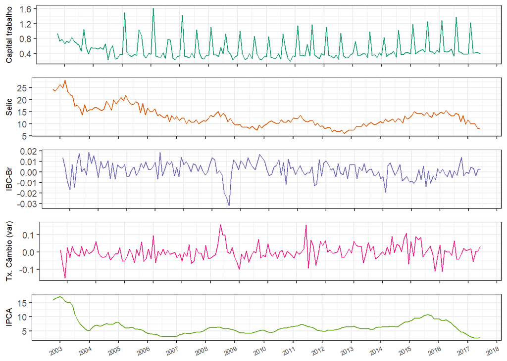

```r
cores <- brewer.pal(5, "Dark2")

# Gráficos individuais
p1 <- ggplot(df2[which(df2$variable == "Capital_trabalho"),], aes(Data, value, colour = variable)) +
        geom_line(alpha = 1, show.legend=F, colour = cores[1])+
        scale_y_continuous(name="Capital trabalho") +
        scale_x_date(date_breaks = "12 months")+
        theme_bw()
p1 <- p1 + theme(axis.text.x=element_blank(), axis.title.x = element_blank(), axis.title.y = element_text(size = 8))

p2 <- ggplot(df2[which(df2$variable == "Selic"),], aes(Data, value, colour = variable)) +
        geom_line(alpha = 1, show.legend=F, colour = cores[2])+
        scale_y_continuous(name="Selic") +
        scale_x_date(date_breaks = "12 months")+
        theme_bw()
p2 <- p2 + theme(axis.text.x=element_blank(), axis.title.x = element_blank(), axis.title.y = element_text(size = 8))

p3 <- ggplot(df2[which(df2$variable == "IBCBr"),], aes(Data, value, colour = variable)) +
        geom_line(alpha = 1, show.legend=F, colour = cores[3])+
        scale_y_continuous(name="IBC-Br") +
        scale_x_date(date_breaks = "12 months")+
        theme_bw()
p3 <- p3 + theme(axis.text.x=element_blank(), axis.title.x = element_blank(), axis.title.y = element_text(size = 8))

p4 <- ggplot(df2[which(df2$variable == "Cambio"),], aes(Data, value, colour = variable)) +
        geom_line(alpha = 1, show.legend=F, colour = cores[4])+
        scale_y_continuous(name="Tx. Câmbio (var)") +
        scale_x_date(date_breaks = "12 months")+
        theme_bw()
p4 <- p4 + theme(axis.text.x=element_blank(), axis.title.x = element_blank(), axis.title.y = element_text(size = 8))

p5 <- ggplot(df2[which(df2$variable == "IPCA"),], aes(Data, value, colour = variable)) +
        geom_line(alpha = 1, show.legend=F, colour = cores[5])+
        scale_y_continuous(name="IPCA") +
        scale_x_date(date_breaks = "12 months", name = "Data", labels = date_format("%Y"))+
        theme_bw()
p5 <- p5 + theme(axis.text.x = element_text(angle=25, hjust = 1, size = 6), axis.title.x = element_blank(), axis.title.y = element_text(size = 8))

grid.arrange(p1, p2, p3, p4, p5, ncol=1, nrow = 5)
```

# A sazonalidade

Agora começa outro problema para tratar os dados: para a razão capital trabalho original, tem 30 observações de antes do plano real que tem valores muito altos. Depois de eliminar elas, tem duas séries com tendência e sazonalidade. A razão entre elas não aparenta ter tendência (fiz um teste que indicou que a série precisaria de uma diferença para ficar estacionária), porém parece ter uma componente sazonal persistente.

Resolvi tentar duas coisas: a primeira foi fazer manualmente a remoção de tendência e sazonalidade e a segunda foi usar um filtro pronto. Meu filtro manual ficou uma merda, então vou ficar com o automático mesmo.

## Procedimento manual

Vou deixar aqui e qualquer coisa apago no final. Os chunks não estão sendo rodados. Usei este tutorial - https://anomaly.io/seasonal-trend-decomposition-in-r/.

### Removendo tendência

Não sei se precisa. Como os dados são mensais, vou usar uma janela móvel de tamanho 12.

```r
# Checa número de diferenciações necessárias para tornar séries estacionárias
ndiffs(capital_trabalho,test="adf",alpha = 0.1)
# De acordo com o teste, seria necessário diferenciar uma vez a série para que ela fique estacionária

# Remove a tendência ajustando uma janela móvel
trend_capital_trabalho = ma(capital_trabalho, order = 12, centre = T)
plot(as.ts(capital_trabalho))
lines(trend_capital_trabalho)
plot(as.ts(trend_capital_trabalho))

df <- as.data.frame(cbind(time(trend_capital_trabalho),trend_capital_trabalho, capital_trabalho))
head(df)
names(df) <- c("Data", "Tendencia", "CapitalTrabalho")
ggplot(df, aes(Data)) +
  geom_line(aes(y = CapitalTrabalho, colour = "Capital/Trabalho")) +
  geom_line(aes(y = Tendencia, colour = "Tendência"))
```

### Removendo sazonalidade

```r
m_capital_trabalho = t(matrix(data = capital_trabalho, nrow = 12))
seasonal_capital_trabalho = colMeans(m_capital_trabalho, na.rm = T)
plot(as.ts(rep(seasonal_capital_trabalho,12)))
```

### Residual

Vamos calcular o “random noise” usando $Resíduo = Série - Sazonalidade - Tendência$.

```r
residuo = capital_trabalho - seasonal_capital_trabalho - trend_capital_trabalho

plot(as.ts(residuo))
```

Ainda assim está meio estranho… Vou tentar usar um filtro automático.

## X-13ARIMA-SEATS

O X-13ARIMA-SEATS é um algoritmo de ajuste sazonal desenvolvido pelo United States Census Bureau. Sua implementação no R é feita pelo pacote `seasonal`. Um manual pode ser visto aqui: https://cran.r-project.org/web/packages/seasonal/vignettes/seas.pdf.

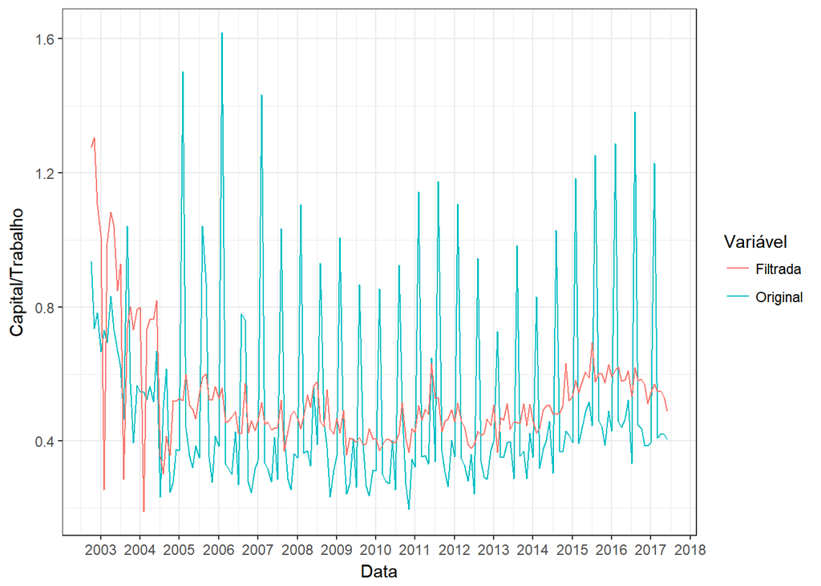

```r
#######################
# Capital trabalho    #
#######################
m <- seas(x = capital_trabalho)
#plot(m)
#summary(m)

# Usa a interface gráfica
#view(m)

# Salva a série final em uma nova variável
capital_trabalho2 <- final(m)
#plot(capital_trabalho2)

# Compara a série ajustada com a série original
df <- data.frame(seq(as.Date(inicio), length = length(capital_trabalho2), by = "1 month"), capital_trabalho, capital_trabalho2)
names(df) <- c("Data", "Original", "Série Filtrada")
p1 <- ggplot(df, aes(Data)) +
  geom_line(aes(y = capital_trabalho, colour = "Original")) +
  geom_line(aes(y = capital_trabalho2, colour = "Filtrada")) +
  scale_x_date(date_breaks = "12 months", name = "Data", labels = date_format("%Y"))+
  scale_y_continuous(name = "Capital/Trabalho")+
  labs(color="Variável") +
  theme_bw()
p1
```

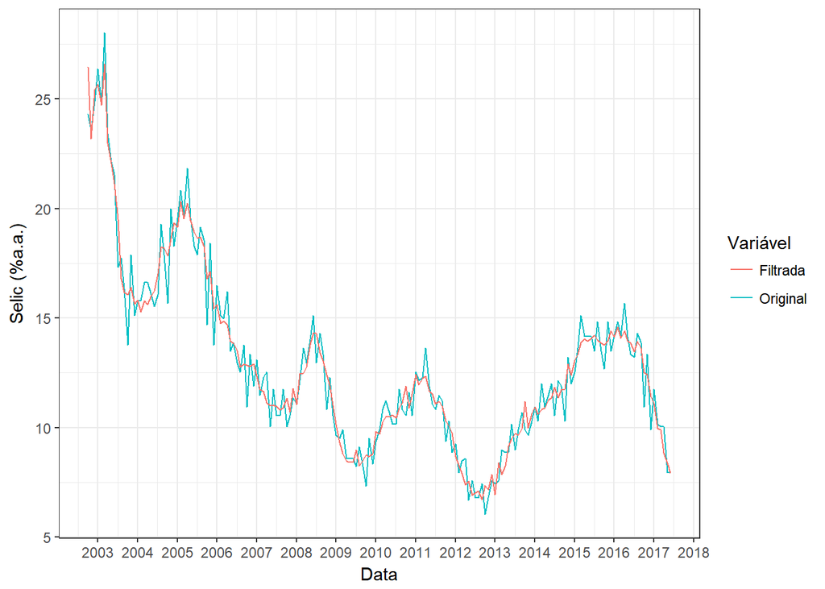

```r
#######################
# Selic               #
#######################

m <- seas(x = selic, transform.function = "none")
#plot(m)
#summary(m)

# Usa a interface gráfica
#view(m)

# Salva a série final em uma nova variável
selic2 <- final(m)

# Compara a série ajustada com a série original
df <- data.frame(seq(as.Date(inicio), length = length(selic2), by = "1 month"), selic, selic2)
names(df) <- c("Data", "Original", "Série Filtrada")
p2 <- ggplot(df, aes(Data)) +
  geom_line(aes(y = selic, colour = "Original")) +
  geom_line(aes(y = selic2, colour = "Filtrada")) +
  scale_x_date(date_breaks = "12 months", name = "Data", labels = date_format("%Y"))+
  scale_y_continuous(name = "Selic (%a.a.)")+
  labs(color="Variável") +
  theme_bw()
p2
```

```r
#######################
# IBC-Br              #
#######################

m <- seas(x = ibcbr)
```

```
## Model used in SEATS is different: (0 2 2)
```

```r
#plot(m)
#summary(m)

# Usa a interface gráfica
#view(m)

# Como ficou igual, também não mexi nele.

#######################
# Câmbio              #
#######################

m <- seas(x = cambio)
#plot(m)
#summary(m)

# Usa a interface gráfica
#view(m)

# Como ficou igual, também não mexi nele.


#######################
# IPCA                #
#######################

m <- seas(x = ipca, transform.function = "none")
```

```
## Model used in SEATS is different: (0 2 1)
```

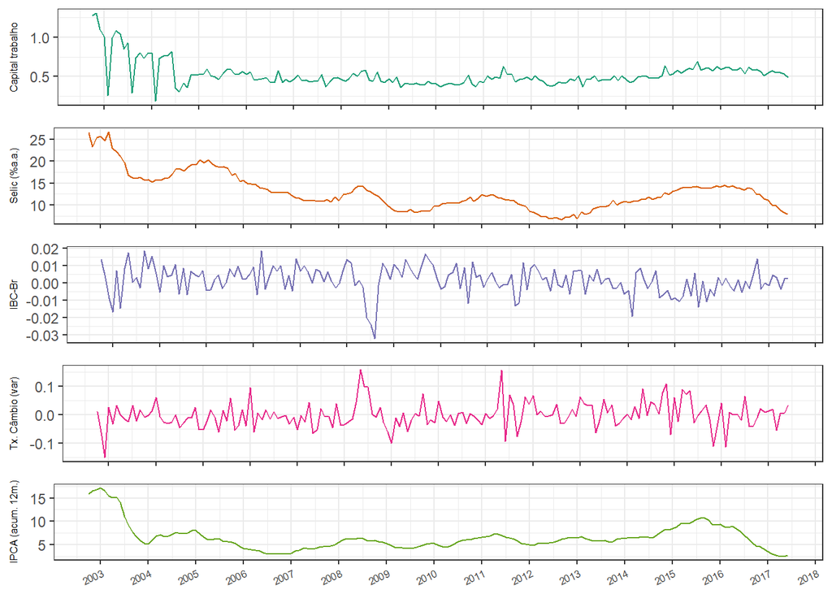

```r
#plot(m)

# Usa a interface gráfica
#view(m)

# Como o IPCA ficou igual, deixei assim mesmo


# Repete o mesmo gráfico de antes, mas com as variáveis dessazonalizadas

df1 <- data.frame(seq(as.Date(inicio), length = length(ipca), by = "1 month"), capital_trabalho2, selic2, ibcbr, cambio, ipca)
names(df1) <- c("Data", "Capital_trabalho", "Selic", "IBCBr", "Cambio", "IPCA")
df2 <- melt(data = df1, id.vars = "Data")

# Gráficos individuais
p1 <- ggplot(df2[which(df2$variable == "Capital_trabalho"),], aes(Data, value, colour = variable)) +
        geom_line(alpha = 1, show.legend=F, colour = cores[1])+
        scale_y_continuous(name="Capital trabalho") +
        scale_x_date(date_breaks = "12 months")+
        theme_bw()
p1 <- p1 + theme(axis.text.x=element_blank(), axis.title.x = element_blank(), axis.title.y = element_text(size = 6))

p2 <- ggplot(df2[which(df2$variable == "Selic"),], aes(Data, value, colour = variable)) +
        geom_line(alpha = 1, show.legend=F, colour = cores[2])+
        scale_y_continuous(name="Selic (%a.a.)") +
        scale_x_date(date_breaks = "12 months")+
        theme_bw()
p2 <- p2 + theme(axis.text.x=element_blank(), axis.title.x = element_blank(), axis.title.y = element_text(size = 6))

p3 <- ggplot(df2[which(df2$variable == "IBCBr"),], aes(Data, value, colour = variable)) +
        geom_line(alpha = 1, show.legend=F, colour = cores[3])+
        scale_y_continuous(name="IBC-Br") +
        scale_x_date(date_breaks = "12 months")+
        theme_bw()
p3 <- p3 + theme(axis.text.x=element_blank(), axis.title.x = element_blank(), axis.title.y = element_text(size = 6))

p4 <- ggplot(df2[which(df2$variable == "Cambio"),], aes(Data, value, colour = variable)) +
        geom_line(alpha = 1, show.legend=F, colour = cores[4])+
        scale_y_continuous(name="Tx. Câmbio (var)") +
        scale_x_date(date_breaks = "12 months")+
        theme_bw()
p4 <- p4 + theme(axis.text.x=element_blank(), axis.title.x = element_blank(), axis.title.y = element_text(size = 6))

p5 <- ggplot(df2[which(df2$variable == "IPCA"),], aes(Data, value, colour = variable)) +
        geom_line(alpha = 1, show.legend=F, colour = cores[5])+
        scale_y_continuous(name="IPCA (acum. 12m.)") +
        scale_x_date(date_breaks = "12 months", name = "Data", labels = date_format("%Y"))+
        theme_bw()
p5 <- p5 + theme(axis.text.x = element_text(angle=25, hjust = 1, size = 6), axis.title.x = element_blank(), axis.title.y = element_text(size = 6))

grid.arrange(p1, p2, p3, p4, p5, ncol=1, nrow = 5)
```

## Descritivas

```r
### Descriptives

descriptives     <- matrix(NA, nrow = 8, ncol = (ncol(df1)-1))
rownames(descriptives) <- c("Observações", "Mínimo", "1o quartil",
                      "Média", "Mediana",  "3o quartil", "Máximo",
                      "Desv. Pad.")

colnames(descriptives) <- names(df1)[-1]

desc <- function(x) {
  n       <- length(x)
  minimum <- min(x, na.rm = TRUE)
  first_q <- quantile(x, 0.25, na.rm = TRUE)
  media   <- mean(x, na.rm = TRUE)
  mediana <- median(x, na.rm = TRUE)
  third_q <- quantile(x, 0.75, na.rm = TRUE)
  maximum <- max(x, na.rm = TRUE)
  std     <- sd(x, na.rm = TRUE)

    return(list(n = n, minimum = minimum, first_quar = first_q, media = media, mediana = mediana, third_quar = third_q, maximum = maximum, std = std))
}

for (i in 1:8){
  descriptives[i, 1] <- round(as.numeric(desc(df1[,2])[i]),4)
  descriptives[i, 2] <- round(as.numeric(desc(df1[,3])[i]),4)
  descriptives[i, 3] <- round(as.numeric(desc(df1[,4])[i]),4)
  descriptives[i, 4] <- round(as.numeric(desc(df1[,5])[i]),4)
  descriptives[i, 5] <- round(as.numeric(desc(df1[,6])[i]),4)
}

descriptives[1,] <- as.integer(descriptives[1,])

descriptives <- data.frame(descriptives)

stargazer(descriptives, summary=FALSE, header = TRUE, type = 'html')
```

|  | Capital_trabalho | Selic | IBCBr | Cambio | IPCA |
| --- | --- | --- | --- | --- | --- |
| Observações | 177 | 177 | 177 | 177 | 177 |
| Mínimo | 0.190 | 6.707 | -0.032 | -0.149 | 2.456 |
| 1o quartil | 0.436 | 10.305 | -0.003 | -0.027 | 4.832 |
| Média | 0.526 | 12.953 | 0.002 | -0.0004 | 6.497 |
| Mediana | 0.493 | 12.263 | 0.002 | -0.005 | 6.037 |
| 3o quartil | 0.570 | 14.416 | 0.007 | 0.022 | 7.138 |
| Máximo | 1.305 | 26.608 | 0.019 | 0.158 | 17.235 |
| Desv. Pad. | 0.163 | 4.105 | 0.008 | 0.045 | 2.799 |

```r
stargazer(descriptives, summary=FALSE, header = TRUE, type = 'latex')
```

% Table created by stargazer v.5.2 by Marek Hlavac, Harvard University. E-mail: hlavac at fas.harvard.edu % Date and time: sáb, jan 13, 2018 - 09:03:07

# Baixando dados de desigualdade

## Lista de dados existentes

# Jogando no liquidificador

O pacote que tem o modelo implementado é o `bvarsv`. Aqui (https://github.com/FK83/bvarsv/blob/master/bvarsv_Nov2015_website.pdf) e aqui (https://github.com/FK83/bvarsv/blob/master/bvarsv_replication.pdf) tem exemplos de uso.

Especificações da função `bvar.sv.tvp`:

- $p$ é o número de defasagens;
- $\tau$ é o número de observações que serão utilizadas para conseguir os hiperparâmetros. O default é 40, usei 24 (2 anos);
- $nf$ é o número de períodos para fazer previsão, o default é 10;
- $pdrift* parâmetro de tendência, default é TRUE;
- As distribuições a priori são as mesmas do Primiceri:
  - $B_0$ são os betas iniciais e seguem uma distribuição normal com parâmetros obtidos usando MQO
  - $A_0$ é a covariância inicial, também tem distribuição normal. As variâncias de $A_0$ e $B_0$ são multiplicadas por 4;
  - $log \ \sigma_0$ é a log volatilidade inicial, também segue uma densidade normal, com média estimada por MQO e variância unitária;
  - $Q$ matriz de variância covariância de $B_t$, tem distribuição inversa-wishart e uns parâmetros meio esquisitos (https://github.com/FK83/bvarsv/blob/master/bvarsv_Nov2015_website.pdf - ver página 2)
  - $W$ é a matriz decovariância dos choques em $log\ \sigma_0$
  - $S_j$ é a matriz de covariância de $A_t$

```r
var1 <- cbind(capital_trabalho2, selic2, ibcbr, cambio, ipca)

set.seed(1)

nburn. <- 5000
nrep. <- 50000

fit1 <- bvar.sv.tvp(var1, p=1, tau = 24, nburn = nburn., nrep = nrep.)
```

```
## [1] "2018-01-13 09:03:09 -- now starting MCMC"
## [1] "2018-01-13 09:07:25 -- now at iteration 5000"
## [1] "2018-01-13 09:15:47 -- now at iteration 15000"
## [1] "2018-01-13 09:24:39 -- now at iteration 25000"
## [1] "2018-01-13 09:33:31 -- now at iteration 35000"
## [1] "2018-01-13 09:42:35 -- now at iteration 45000"
## [1] "2018-01-13 09:51:18 -- now at iteration 55000"
```

```r
# Plots

## Colocando as datas como strings

tm1 <- as.yearmon(time(var1))

## Peguei essa função pronta

matplot2 <- function(...){
  matplot(..., type = 'l', lty = 1, lwd = 2, bty = "n", ylab = "")
}

# Essa função calcula os quantis e organiza 1 quantil, média, 3 quantil.
stat.helper <- function(z) c(mean(z), quantile(z, c(0.16, 0.84)))[c(2,1,3)]

# Eixo x
xax <- time(var1)
# Perde uma observação pelo lag e outras 24 pela amostra para estimar por MQO, então começa no tempo 26
xax <- xax[26:177]

# Marcas verticais
gp <- seq(1999, 2017, 1)

# Paleta de cores
cbPalette <- c("#999999", "#E69F00", "#56B4E9", "#009E73", "#F0E442", "#0072B2", "#D55E00", "#CC79A7")

cols1 <- cbPalette[c(2,4,2)]
cols2 <- cbPalette[c(2,4,6)]
```

```r
# Gráfico do desvio padrão do resíduo da razão capital trabalho
sd_ct <- parameter.draws(fit1, type = "vcv", row = 1, col = 1)
```

```
## Element [1,1] of vcv matrix. Format: MCMC draws in rows, time in columns.
```

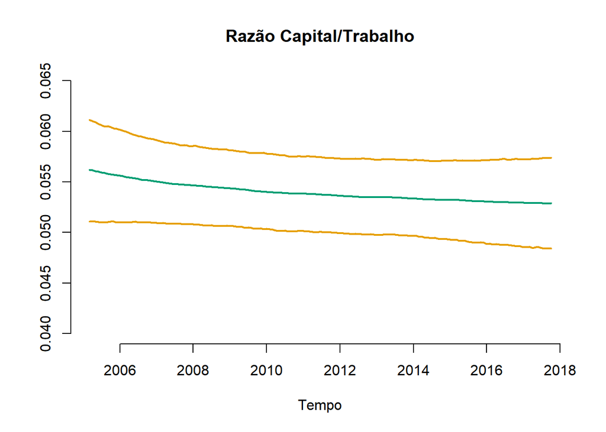

```r
x1 <- t(apply(sqrt(sd_ct), 2, stat.helper))
matplot2(x = xax, y = x1, ylim = c(0.04, 0.065), col = cols1, main = "Razão Capital/Trabalho", xlab = "Tempo")
```

```r
# Gráfico do desvio padrão do resíduo da selic
sd_selic <- parameter.draws(fit1, type = "vcv", row = 2, col = 2)
```

```
## Element [2,2] of vcv matrix. Format: MCMC draws in rows, time in columns.
```

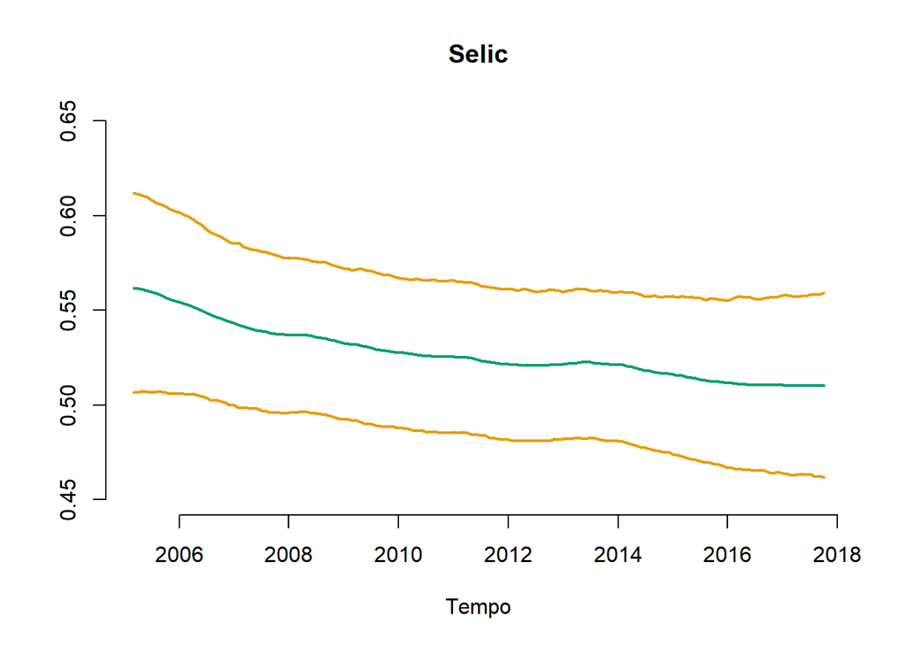

```r
x2 <- t(apply(sqrt(sd_selic), 2, stat.helper))
matplot2(x = xax, y = x2, ylim = c(0.45, 0.65), col = cols1, main = "Selic", xlab = "Tempo")
```

```r
# Gráfico do desvio padrão do resíduo do ibcbr
sd_ibcbr <- parameter.draws(fit1, type = "vcv", row = 3, col = 3)
```

```
## Element [3,3] of vcv matrix. Format: MCMC draws in rows, time in columns.
```

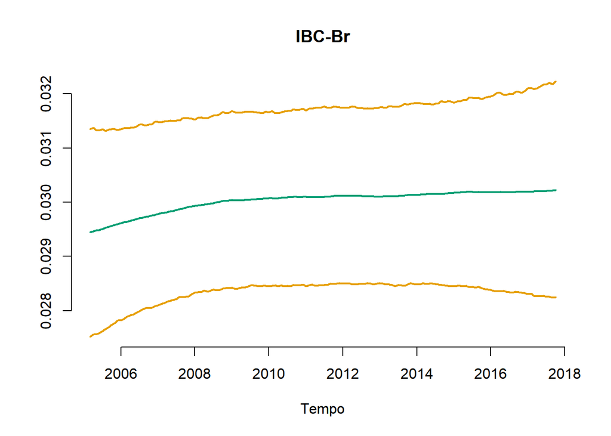

```r
x3 <- t(apply(sqrt(sd_ibcbr), 2, stat.helper))
matplot2(x = xax, y = x3, col = cols1, main = "IBC-Br", xlab = "Tempo")
```

```r
# Gráfico do desvio padrão do resíduo do cambio
sd_cambio <- parameter.draws(fit1, type = "vcv", row = 4, col = 4)
```

```
## Element [4,4] of vcv matrix. Format: MCMC draws in rows, time in columns.
```

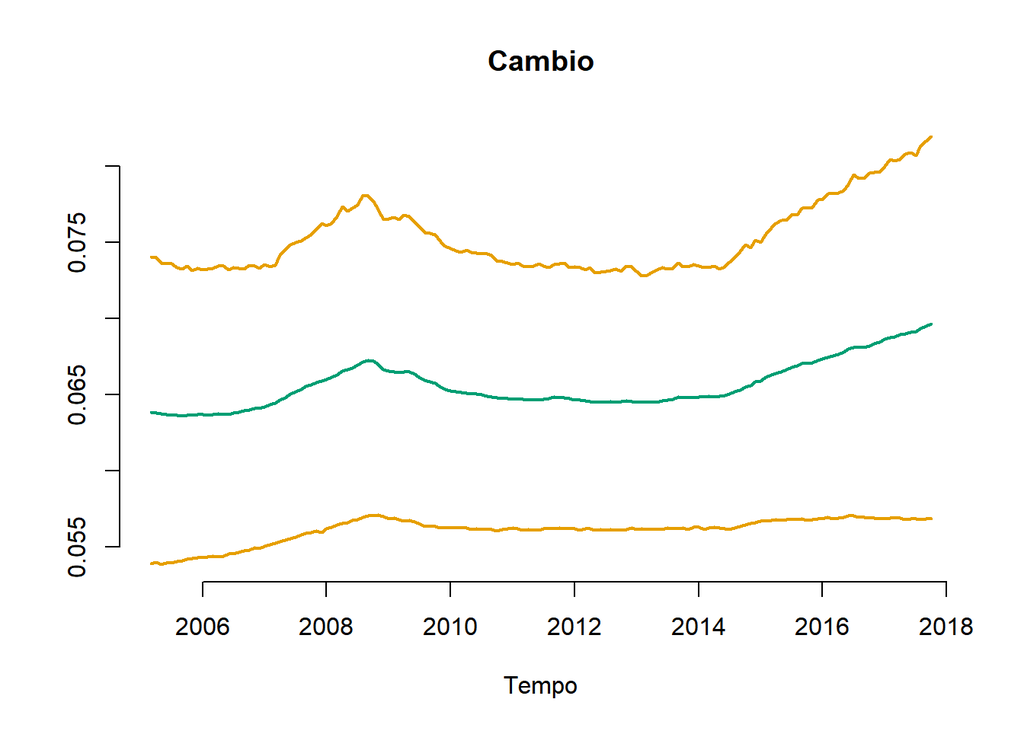

```r
x4 <- t(apply(sqrt(sd_cambio), 2, stat.helper))
matplot2(x = xax, y = x4, col = cols1, main = "Cambio", xlab = "Tempo")
```

```r
# Gráfico do desvio padrão do resíduo do ipca
sd_ipca <- parameter.draws(fit1, type = "vcv", row = 5, col = 5)
```

```
## Element [5,5] of vcv matrix. Format: MCMC draws in rows, time in columns.
```

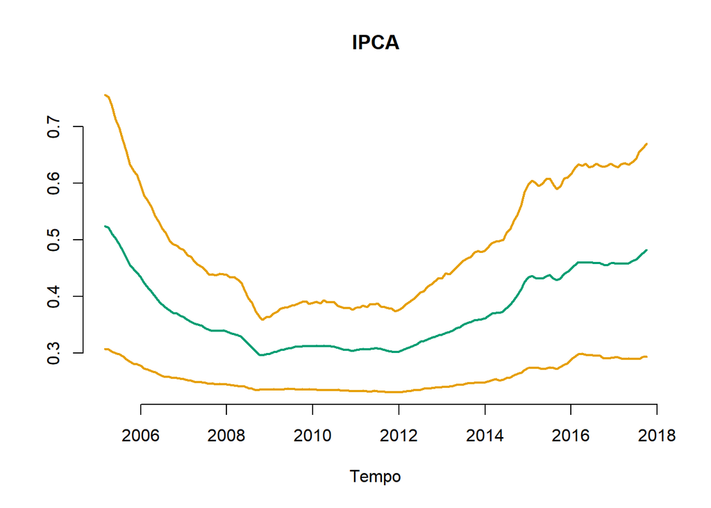

```r
x5 <- t(apply(sqrt(sd_ipca), 2, stat.helper))
matplot2(x = xax, y = x5, col = cols1, main = "IPCA", xlab = "Tempo")
```

```r
# Função Impulso resposta
ira <- impulse.responses(fit1, impulse.variable = 2, response.variable = 1)
```

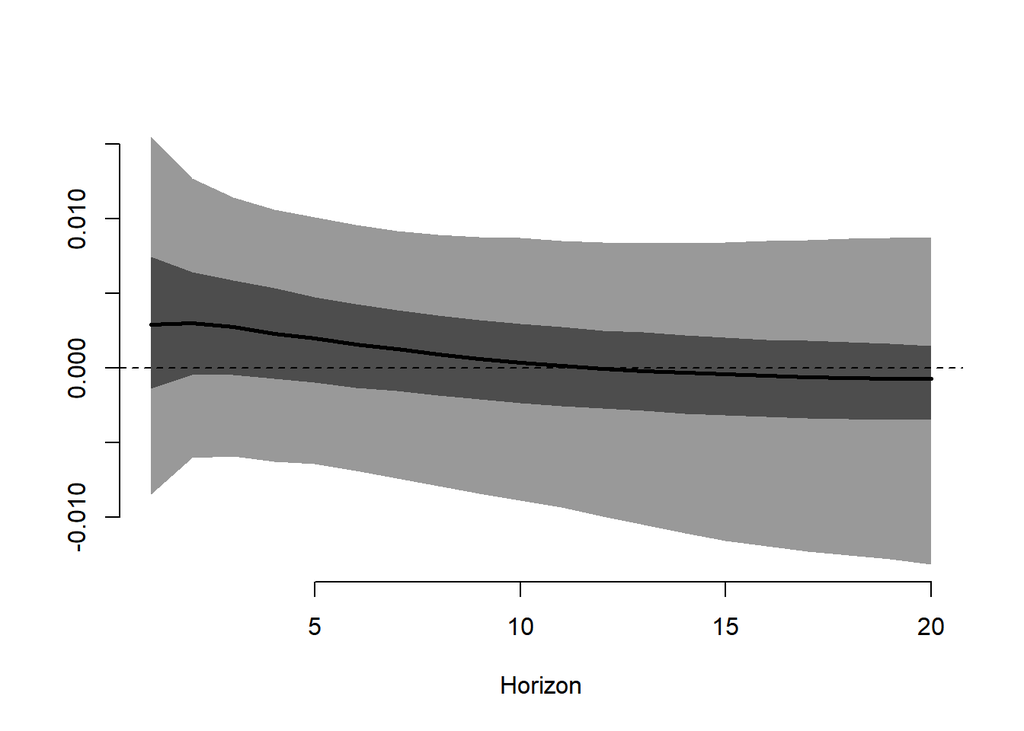

```r
ira <- impulse.responses(fit1, impulse.variable = 2, response.variable = 3)
```

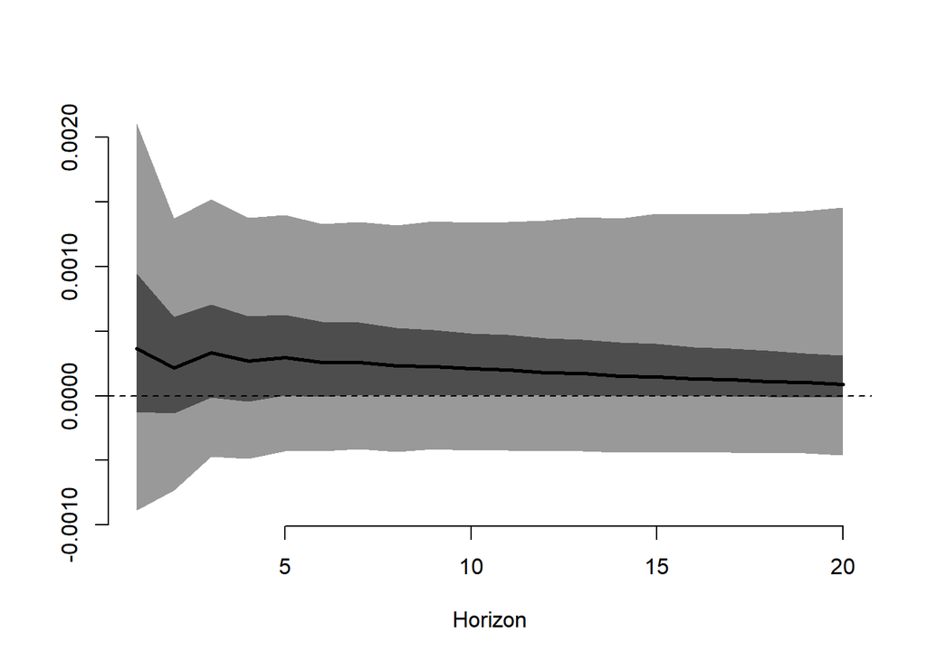

```r
ira <- impulse.responses(fit1, impulse.variable = 2, response.variable = 4)
```

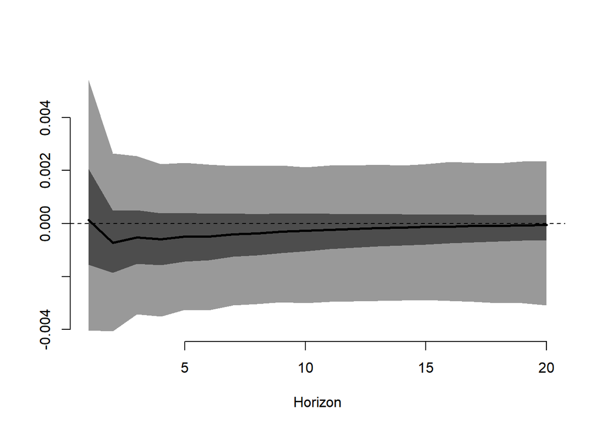

```r
ira <- impulse.responses(fit1, impulse.variable = 2, response.variable = 5)
```

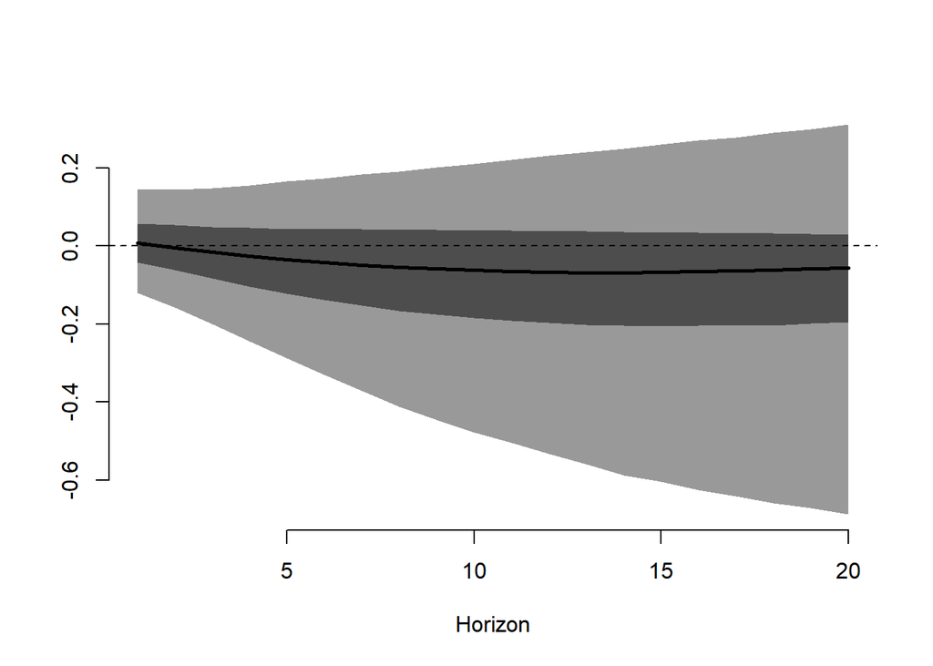

```r
ira <- impulse.responses(fit1, impulse.variable = 5, response.variable = 2)
```

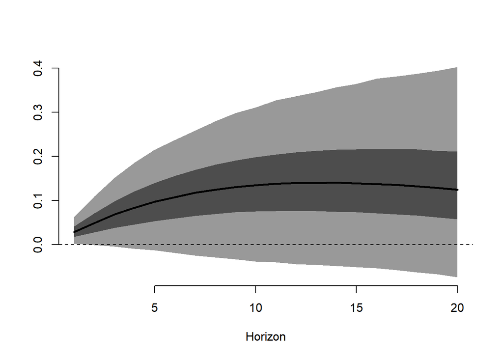

As variáveis com o modelo completo apresentam menor variação no desvio padrão dos resíduos do que quando fiz um var so com selic e razão capital trabalho (se bem que quando eu fiz isso, era com dados desde 1994). É possível que as coisas tenham ficado relativamente estáveis a partir do ano que eu estou analisando.

# Coisas a serem pensadas

- Uma coisa a ser feita é jogar esse IBC-Br fora e aumentar um pouco a amostra para ver o que acontece.
- Tem a questão do câmbio também pra ser vista.
- E a questão da priori, talvez mude os resultados se eu mudar ela.